# Math 120 Lec 01

Ali Miller

21 August, 2020

# Math 120 Week 1

## Wednesday Aug 19

Alright, introductions are over – let’s do some math!

The program I’m using to write these notes is called RStudio. It uses the programming language “R”. You **don’t** need to know how to use either of these for this class, but you’ll acclimate to it as the semester goes on. If you want to learn more about R, feel free to talk to me about it in office hours!

The main reason I like to use RStudio is that it lets me perform computations just as easily as typing. Check this out:

```r
1+1
```

```
## [1] 2
```

Also, it lets me work directly with datasets. Here’s an example of the famous “iris” dataset that we’ll see in HW later:

```r
head(iris)
```

|  | Sepal.Length | Sepal.Width | Petal.Length | Petal.Width | Species |
| --- | --- | --- | --- | --- | --- |
| 1 | 5.1 | 3.5 | 1.4 | 0.2 | setosa |
| 2 | 4.9 | 3.0 | 1.4 | 0.2 | setosa |
| 3 | 4.7 | 3.2 | 1.3 | 0.2 | setosa |
| 4 | 4.6 | 3.1 | 1.5 | 0.2 | setosa |
| 5 | 5.0 | 3.6 | 1.4 | 0.2 | setosa |
| 6 | 5.4 | 3.9 | 1.7 | 0.4 | setosa |

Woah! Neat right? Whenever you see anything in the grey box, that’s a statistical operation or computation. Think: grey box == math stuff.

Keep in mind, I’ll be posting these notes on my website: millera2.github.io . Definitely **do** take notes! But, don’t worry about writing every word.

Ready? Let’s do this!

### Data – What is it?

Statistics is the mathematical science of analyzing data. But, we should ask an important question –

What is data?

There are a lot of important details here. But fist, let’s gather some data of our own.

To the internet! Check your email!

### Rectangular Data

The dataset we collected above was an example of a specific kind of dataset – **rectangular** or **tabular** data. Data Analytics people call it “Tidy” data, but that’s silly. ;D Here, we’ll call it a rectangular dataset.

What are the key features?

1. Each row is: an observation, i.e., an individual in the data
2. Each column is:a variable, i.e. a specific quality of the observations
3. Each individual entry is: a cell, i.e., a specific value for an individual observation.

Datasets like this one are the starting point for our analysis as statisticians.

### Types of Variables

You all entered data about four different variables:

1. No of Siblings
2. Year in School
3. Hair Color
4. Height

I picked these stratigically to illustrate the different types of data that we see in the wild.

First, we can categorize all data in two ways:

- **numerical/quantitative**
- **cagtegorical/qualitative**

For both kinds, we can make important distinctions:

Numerical/Quantitative Data can be either:

- **Discrete**. Things that are countable!
  - Examples: # of students in this class, # of siblings
- **Continuous**. Anything that can be *measured*. Could be *any* real number.
  - Examples: Weight, height, volume, time taken, distance, area, etc et. Basically any physical measurement.

Wierd example: money. Let’s agree, here in Math 120, that money is continuous. Kinda weird, because you can’t have $0.004652 dollars. BUT, interest is computed continuously.

Categorical Data can be either

- **Ordinal**. Has a natural order to it.
  - Examples: Year in school.
- **Nominal**. No natural order.
  - Examples: Hair color, nationality, gender, etc. etc.

Understanding what kind of data you’re using is **absolutely critical** in any statistical analysis! We need different tools to analyze different types of data!

Example: What’s the “average hair color” of students in this class?

Dunno, doesn’t make sense!

Example: What percent of students in this class are 65.237 inches tall?

Doesn’t make sense to talk about specific continuous value!

### Metadata

In order to use any dataset effectively, we need documentation about what it’s rows (observations) and columns (variables) actually describe.

This document is called the “metadata” for the dataset. Metadata literally means, “data about data”.

Usually, these documents don’t have a specific format. Instead, they’re inteded for human use – i.e., **you** have to read them and understand what they mean.

### Example: MPG Data

One of the example datasets that we’ll look at in class is a historical dataset called “mpg”. The first few rows are shown below. Can you guess what the data is about? Cars!

```r
head(mpg)
```

| manufacturer | model | displ | year | cyl | trans | drv | cty | hwy | fl | class |
| --- | --- | --- | --- | --- | --- | --- | --- | --- | --- | --- |
| audi | a4 | 1.8 | 1999 | 4 | auto(l5) | f | 18 | 29 | p | compact |
| audi | a4 | 1.8 | 1999 | 4 | manual(m5) | f | 21 | 29 | p | compact |
| audi | a4 | 2.0 | 2008 | 4 | manual(m6) | f | 20 | 31 | p | compact |
| audi | a4 | 2.0 | 2008 | 4 | auto(av) | f | 21 | 30 | p | compact |
| audi | a4 | 2.8 | 1999 | 6 | auto(l5) | f | 16 | 26 | p | compact |
| audi | a4 | 2.8 | 1999 | 6 | manual(m5) | f | 18 | 26 | p | compact |

Tricky example: year is ordinal! Not counting anything, so not dicrete. Same for all dates and days.

Tricky example: fuel efficiency is cts, even though rounded to whole number!

Let’s take a look at the metadata together. If you’re reading later on, [here is the link](https://ggplot2.tidyverse.org/reference/mpg.html).

## Friday Aug 21

(subject to change!)

### Summary Statistics For Quantitative Data

We humans can only remember a handful of numbers at a time. So, it’s impossible for us to make smart conclusions simply by reading a dataset.

We need to summarize it somehow!

As we saw above, the tools we use depends on the type of data we have. Let’s talk about quantitative variables first.

### Data Visualization For A Single Quantitative Variable

You know what they say – a picture is worth a thousand words.

Before we do any mathematical analyis of a dataset, we **always** look at a picture first!

Q: What’s the right picture? A: It depends on the data!!!

This is critical: different data (nominal, ordinal, continuous, discrete) requires different tools for analysis. Picking the right tool takes study and practice!

We’re talking about quantitative variables right now (i.e. numbers).

If we’re studying a **single quantitative variable**, then our go-to visualization is a **histogram**. Let’ look at an example right now from the student survey you guys contributed.

```r
head(studentSurvey)
```

| Student | Number of Siblings | Year in school | Hair Color | Height in inches |
| --- | --- | --- | --- | --- |
| Student 1 | 3 | Fresh | Brown | 65 |
| Student 2 | 1 | Soph | Black | 74 |
| Student 3 | 1 | Sen | Black | 60 |
| Student 4 | 1 | Jun | Brown | 70 |
| Student 5 | 1 | Jun | Brown | 67 |
| Student 6 | 1 | Sen | Brown | 72 |

#### Histogram of Your Heights

Below is some code that will generate the histogram. YOU DON’T NEED TO KNOW THIS CODE! But, YOU DO NEED TO UNDERSTAND THE HISTOGRAM!

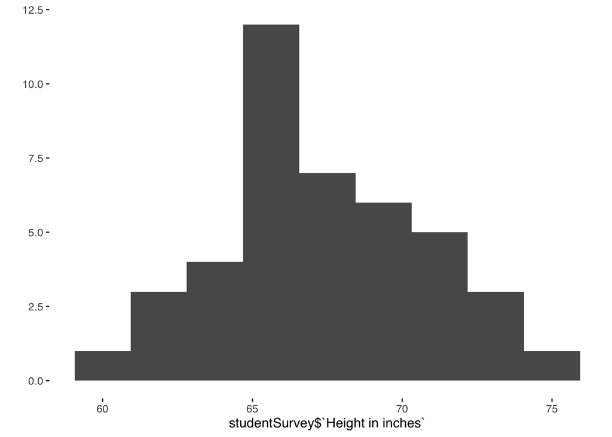

```r
qplot(studentSurvey$`Height in inches`, bins=9)
```

#### Histogram of Num Siblings

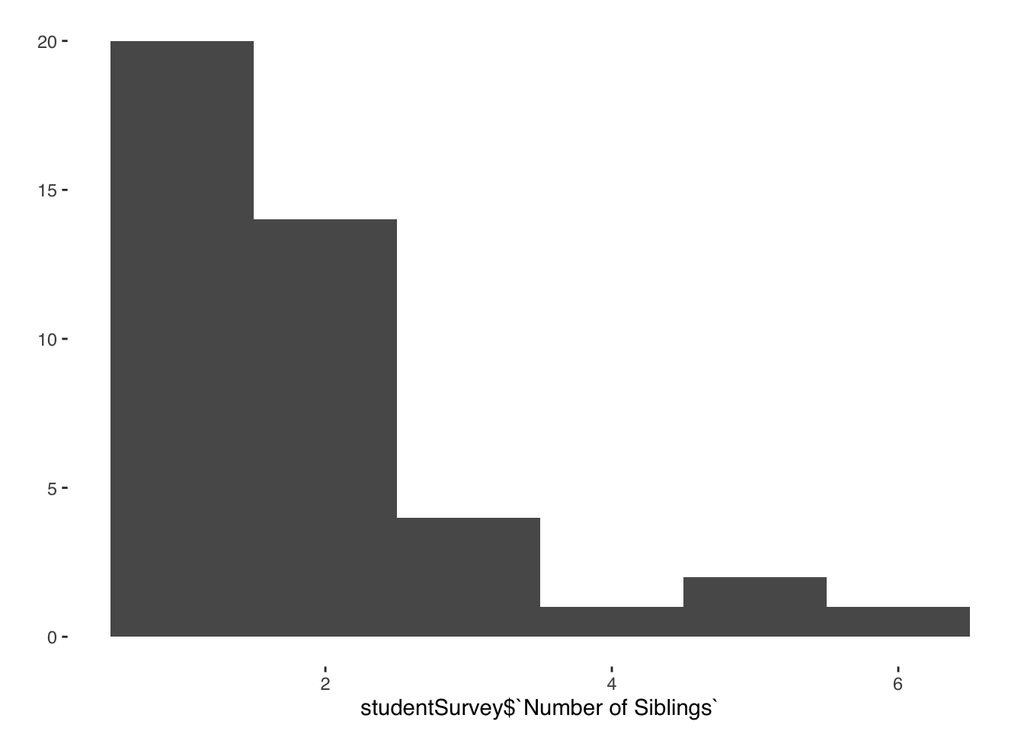

```r
qplot(studentSurvey$`Number of Siblings`, bins=6)
```

### Distributions

For any variable, the “distribution” simply means the list of observations for that variable. Since we’re talking about quantitative/numerical variables now, let’s think about the distributions for # of siblings and height.

There are three major things we want to say about quantitative distributions:

1. Center of the distribution:
2. Spread of the distribution:
3. Shape of the distribution:

There are a several common shapes. In particular, we care about:

- Symmetry:
- Skew:
- Modality:

### Measures of Center

A measure of center is mathematical measure of what’s “typical” in a dataset.

Note that these are all different! Depending on the data, they can give you dramatically different results!

**Example**

Suppose a dataset has the following measurements:

1, 1, 1, 1, 1, 19

What are the mean, median, and mode of this dataset?

**Example: Your Siblings**

**Example: Predicting the Shape of a Distribution**

Let’s look at some HW exercises: 2.15 and 2.16 (p58 and 59)

### Measures of Spread

Here’s the formula for computing standard deviation.

*As you embark upon your journey to understand mathematics, I invite you to appreciate the timeless aesthetic and simplicity of this style of communication. It’s a beautiful gift from our human ancestors across the globe.*

$$s=\sqrt{\frac{\sum{(x_i-\bar{x})^2}}{n-1}}$$